# Example: Study on Dynamics of Depression

This is an illustrative example to convey the concept of the study, focusing on the dynamics of depression using mechanistic models and statistical network models.

## 1. Underlying mechanism

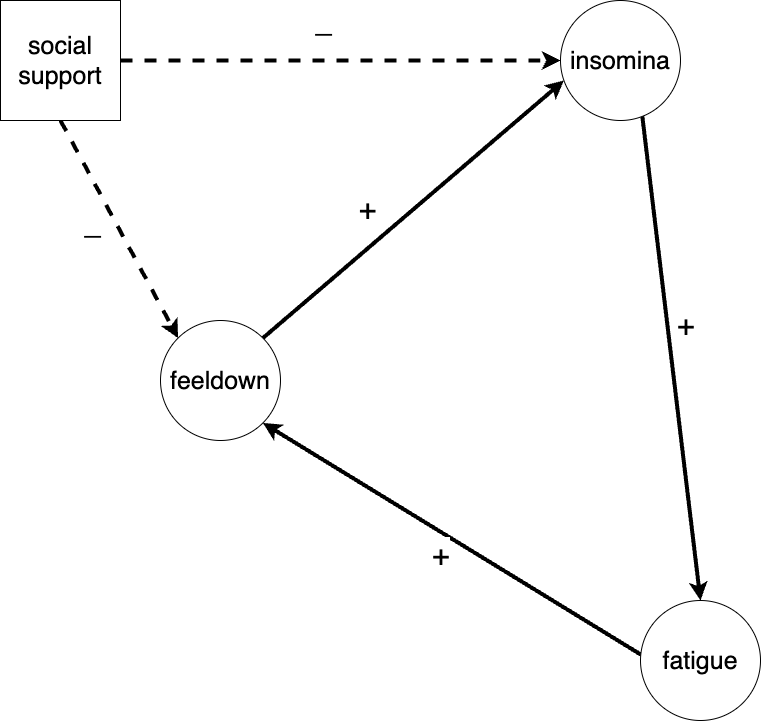

$S_a$ = insomnia, $S_b$ = fatigue, $S_c$ = feeldown, $SS$ = social support.

## 2. Simulating mechanism

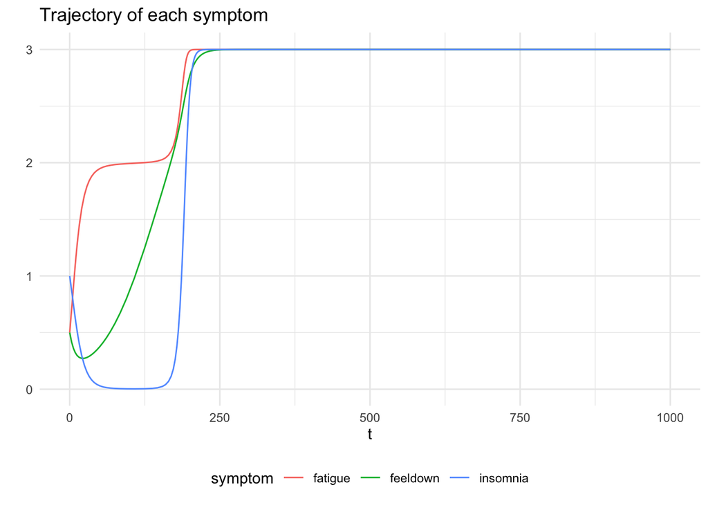

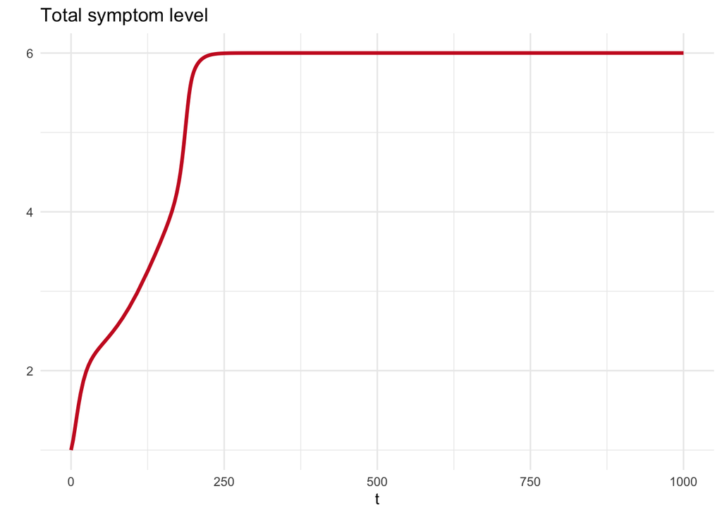

```r
fn1 <- function(t, y, p, ss) {
    a <- p[1]; b <- p[2]
    c <- p[3]; d <- p[4]
    e <- p[4]; f <- p[5]
    g <- p[6]; h <- p[7]
    dx <- a*y[1]*(1 - y[1]/3) * (b*y[3] - p[6]*ss)
    dy <- c*y[2]*(1 - y[2]/3) * d*y[1]
    dz <- e*y[3]*(1 - y[3]/3) * (f*y[2] - p[7]*ss)
    c(dx, dy, dz)
}

p0 <- c(0.29, 0.41, 0.44, 0.32, 0.20, 0.4, 0.33, 0.33)
ic <- c(1.0, 0.5, 0.5)
ss <- 1 # social support

sol1 <- pracma::ode45(fn1, 0, 1000, ic, p = p0, ss = ss) |>
  as.data.frame() |>
  rename(insomnia = y.1, fatigue = y.2, feeldown = y.3)
# sol1$jittered <- apply(sol1$y, 2, function(x) x + rnorm(nrow(sol1$y), sd = 0.03))

sol1 |> tidyr::pivot_longer(!t, names_to = "symptom") |>
  ggplot(aes(x = t, y = value, group = symptom)) +
  geom_line(aes(color=symptom)) + theme_minimal() +
  labs(title = "Trajectory of each symptom", y = "") +
  theme(legend.position = "bottom")
sol1 |>
  rowwise() |>
  mutate(total = sum(c_across(fatigue:feeldown))) |>
  ggplot(aes(x = t, y = total)) +
  geom_line(color = "#CB2027", linewidth=1.2) + theme_minimal() +
  labs(title = "Total symptom level", y = "")
# ggpubr::ggarrange(p1, p2, nrow=2, heights = c(10,8))
```

## 3. Statistical network estimation

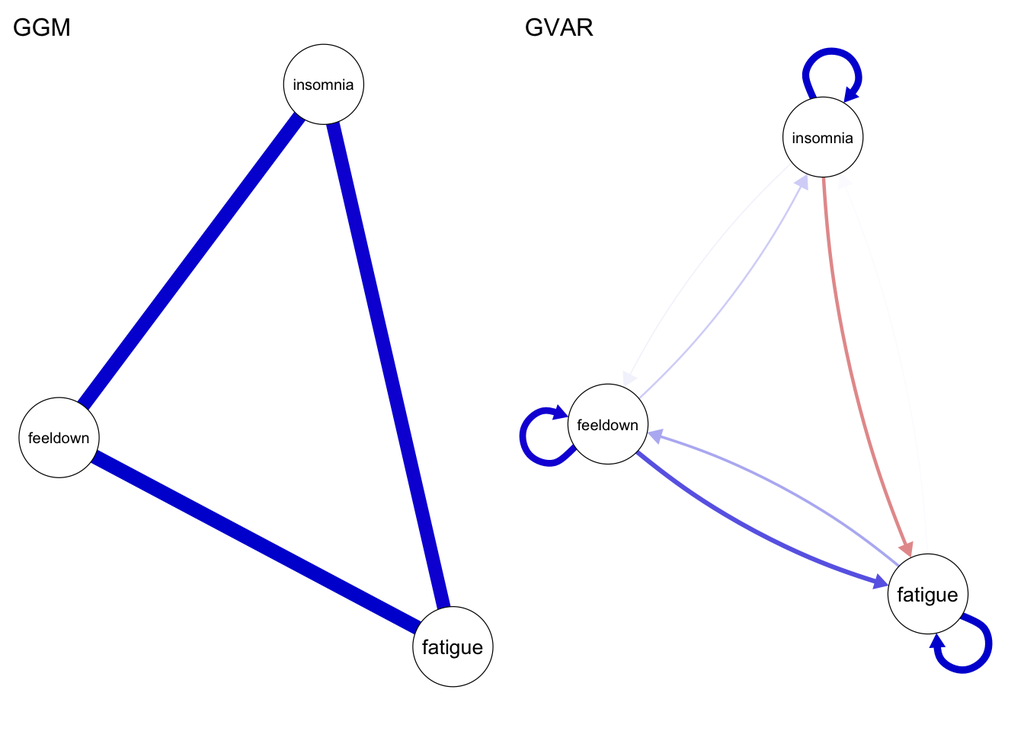

```r
layout(t(1:2))
chosen_var <- c("insomnia", "fatigue", "feeldown")
res1 <- gvar(sol1[1:250,], vars = chosen_var, estimator="FIML") %>% runmodel
# temporal network
temporal1 <- getmatrix(res1, "PDC") # PDC = Partial Directed Correlations
# layout
L <- averageLayout(cor(sol1[-1]), temporal1)
L2 <- L
L2[3,] <- L[2,]; L2[2,] <- L[1,]; L2[1,] <- L[3,]
# cross-sectioanl network
qgraph(cor(sol1[-1]), theme = "colorblind", title = "GGM",
               labels = chosen_var, vsize = 12, layout= L2)
# vector-autoregression network
qgraph(temporal1, theme = "colorblind", directed=TRUE, diag=TRUE,
title = "GVAR", vsize = 12, mar = rep(6,4), labels = chosen_var, layout = L2, asize = 5)
```

> *Why do we get such a GGM?*

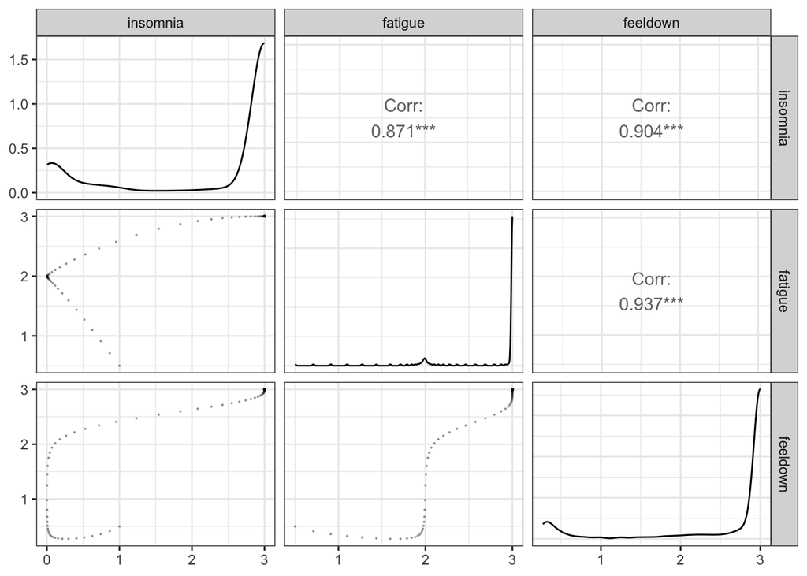

```r
# pairs plot: show correlations
ggpairs(sol1[-1],
        lower = list(continuous = wrap("points", alpha = 0.3, size=0.1))) +
  theme_bw()
```

## 4. Main Focus

- Analyze the key environmental factors that is relevant to the precarious environment. We will try to start with a small model and depending on the results we gain, and potentially we would extend the model by incorporating additional precarious-related factors.
- Formalize relationships between variables; a pivotal aspect of our study. This part is going to the most crucial for our study, which will involve extensive literature review and probably lots of trial and error. This is also where the data comes in: we will fine-tune the parameters based on data.
  - *HELIUS cross-sectional; would it be more useful (better estimate) to use the data with multiple waves?*
- Compare findings with statistical network models. We will fit the simulated data generated by our model to evaluate the inferences drawn and determine their alignment with the original model. There is still some flexibility in this comparison; whether we use time-series network or perhaps we could fit cross-sectional network across multiple time points.